# AIML_P1

**Project Assignment - Gaurav Purwar**

**Description Objective**

Explore the dataset to identify differences between the customers of each product. You can also explore relationships between the different attributes of the customers. You can approach it from any other line of questioning that you feel could be relevant for the business. The idea is to get you comfortable working in Python.

You are expected to do the following :

1. Come up with a customer profile (characteristics of a customer) of the different products
2. Perform univariate and multivariate analyses
3. Generate a set of insights and recommendations that will help the company in targeting new customers.

**Data Dictionary**

The data is about customers of the treadmill product(s) of a retail store called Cardio Good Fitness. It contains the following variables-

1. Product - The model no. of the treadmill
2. Age - Age of the customer in no of years
3. Gender - Gender of the customer
4. Education - Education of the customer in no. of years
5. Marital Status - Marital status of the customer
6. Usage - Avg. # times the customer wants to use the treadmill every week
7. Fitness - Self rated fitness score of the customer (5 - very fit, 1 - very unfit)
8. Income - Income of the customer
9. Miles- Miles that a customer expects to run

# Import all required libararies and read data

```python
from google.colab import drive
drive.mount('/content/drive')
```

Reference all required libarary to complete this assignment

```python
import pandas as pd # To read and modify data
import numpy as np # To do all numberic operations
import matplotlib.pyplot as plt # Data visualization
import seaborn as sns # Data visualization
```

```python
# Set full file path
path = '/content/drive/MyDrive/Python/Assignments/CardioGoodFitness.csv'
```

```python
# load file into notebook and saved into variable for furthur processing
df = pd.read_csv(path)
df
```

|  | Product | Age | Gender | Education | MaritalStatus | Usage | Fitness | Income | Miles |
| --- | --- | --- | --- | --- | --- | --- | --- | --- | --- |
| 0 | TM195 | 18 | Male | 14 | Single | 3 | 4 | 29562 | 112 |
| 1 | TM195 | 19 | Male | 15 | Single | 2 | 3 | 31836 | 75 |
| 2 | TM195 | 19 | Female | 14 | Partnered | 4 | 3 | 30699 | 66 |
| 3 | TM195 | 19 | Male | 12 | Single | 3 | 3 | 32973 | 85 |
| 4 | TM195 | 20 | Male | 13 | Partnered | 4 | 2 | 35247 | 47 |
| ... | ... | ... | ... | ... | ... | ... | ... | ... | ... |
| 175 | TM798 | 40 | Male | 21 | Single | 6 | 5 | 83416 | 200 |
| 176 | TM798 | 42 | Male | 18 | Single | 5 | 4 | 89641 | 200 |
| 177 | TM798 | 45 | Male | 16 | Single | 5 | 5 | 90886 | 160 |
| 178 | TM798 | 47 | Male | 18 | Partnered | 4 | 5 | 104581 | 120 |
| 179 | TM798 | 48 | Male | 18 | Partnered | 4 | 5 | 95508 | 180 |

180 rows × 9 columns

# Understanding the structure of the data

```python
# To find total numbers of rows and columns in dataset
df.shape
```

```
(180, 9)
```

```python
# To find total columns name
df.columns
```

```
Index(['Product', 'Age', 'Gender', 'Education', 'MaritalStatus', 'Usage',
       'Fitness', 'Income', 'Miles'],
      dtype='object')
```

```python
# To find if any null(NaN) in dataset
# Non zero number means missing values present in dataset
# '0' means no missing values present in dataset
df.isnull().sum()
```

```
Product          0
Age              0
Gender           0
Education        0
MaritalStatus    0
Usage            0
Fitness          0
Income           0
Miles            0
dtype: int64
```

**Observations**

1. None of the data frame columns are null.

```python
# To get first 5 rows from dataset
df.head()
```

|  | Product | Age | Gender | Education | MaritalStatus | Usage | Fitness | Income | Miles |
| --- | --- | --- | --- | --- | --- | --- | --- | --- | --- |
| 0 | TM195 | 18 | Male | 14 | Single | 3 | 4 | 29562 | 112 |
| 1 | TM195 | 19 | Male | 15 | Single | 2 | 3 | 31836 | 75 |
| 2 | TM195 | 19 | Female | 14 | Partnered | 4 | 3 | 30699 | 66 |
| 3 | TM195 | 19 | Male | 12 | Single | 3 | 3 | 32973 | 85 |
| 4 | TM195 | 20 | Male | 13 | Partnered | 4 | 2 | 35247 | 47 |

```python
# To get bottom 5 rows from dataset
df.tail()
```

|  | Product | Age | Gender | Education | MaritalStatus | Usage | Fitness | Income | Miles |
| --- | --- | --- | --- | --- | --- | --- | --- | --- | --- |
| 175 | TM798 | 40 | Male | 21 | Single | 6 | 5 | 83416 | 200 |
| 176 | TM798 | 42 | Male | 18 | Single | 5 | 4 | 89641 | 200 |
| 177 | TM798 | 45 | Male | 16 | Single | 5 | 5 | 90886 | 160 |
| 178 | TM798 | 47 | Male | 18 | Partnered | 4 | 5 | 104581 | 120 |
| 179 | TM798 | 48 | Male | 18 | Partnered | 4 | 5 | 95508 | 180 |

```python
# To get Statistical summary of dataset
# This will give Statistical summary of numeric data columns
df.describe().T
```

|  | count | mean | std | min | 25% | 50% | 75% | max |
| --- | --- | --- | --- | --- | --- | --- | --- | --- |
| Age | 180.0 | 28.788889 | 6.943498 | 18.0 | 24.00 | 26.0 | 33.00 | 50.0 |
| Education | 180.0 | 15.572222 | 1.617055 | 12.0 | 14.00 | 16.0 | 16.00 | 21.0 |
| Usage | 180.0 | 3.455556 | 1.084797 | 2.0 | 3.00 | 3.0 | 4.00 | 7.0 |
| Fitness | 180.0 | 3.311111 | 0.958869 | 1.0 | 3.00 | 3.0 | 4.00 | 5.0 |
| Income | 180.0 | 53719.577778 | 16506.684226 | 29562.0 | 44058.75 | 50596.5 | 58668.00 | 104581.0 |
| Miles | 180.0 | 103.194444 | 51.863605 | 21.0 | 66.00 | 94.0 | 114.75 | 360.0 |

```python
# To find out the datatype of each columns
df.info()
```

```
<class 'pandas.core.frame.DataFrame'>
RangeIndex: 180 entries, 0 to 179
Data columns (total 9 columns):
 #   Column         Non-Null Count  Dtype
---  ------         --------------  -----
 0   Product        180 non-null    object
 1   Age            180 non-null    int64
 2   Gender         180 non-null    object
 3   Education      180 non-null    int64
 4   MaritalStatus  180 non-null    object
 5   Usage          180 non-null    int64
 6   Fitness        180 non-null    int64
 7   Income         180 non-null    int64
 8   Miles          180 non-null    int64
dtypes: int64(6), object(3)
memory usage: 12.8+ KB
```

# Univariate Data Analysis

```python
# Function to create box and histogram plot
def histogram_boxplot(data,feature,figsize=(15,7),kde=False,bins=None):
  f2, (ax_box2,ax_hist2) = plt.subplots(nrows=2,
                                        sharex=True,
                                        figsize=figsize,
                                        gridspec_kw={"height_ratios": (.25,.75)}
      )

  # Draw Box Plot
  sns.boxplot(data=data,x=feature,ax=ax_box2,showmeans=True,color="mediumturquoise")

  # Draw Histogram
  if bins:
    sns.histplot(data=data,x=feature,ax=ax_hist2,kde=kde,bins=bins,color="mediumpurple")
  else:
     sns.histplot(data=data,x=feature,ax=ax_hist2,kde=kde,color="mediumpurple")

  # Draw mean and median
  ax_hist2.axvline(data[feature].mean(),color='green',linestyle='--')
  ax_hist2.axvline(data[feature].median(),color='black',linestyle='-')
```

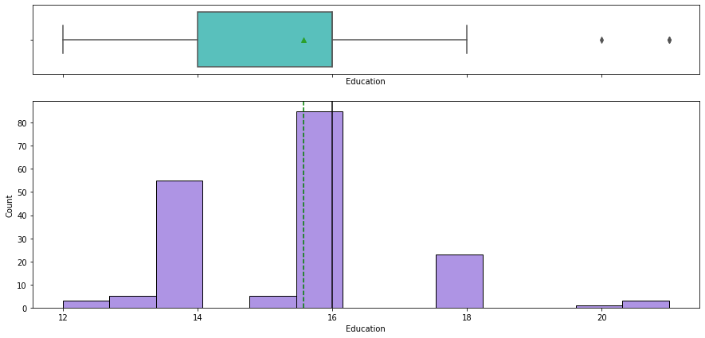

```python
histogram_boxplot(df,'Education')
```

**Observations**

1. Most of the customers having education year 16.

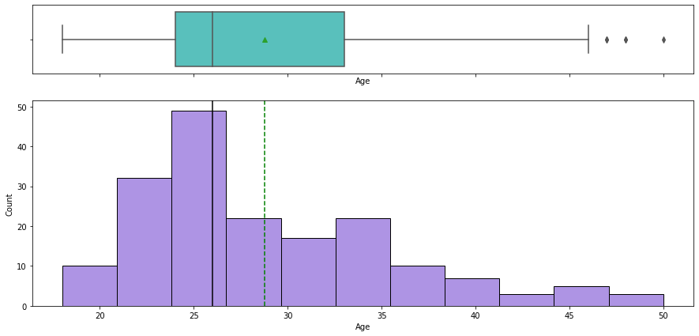

```python
histogram_boxplot(df,'Age')
```

**Observations**

1. Most of customers are from age 24-26.

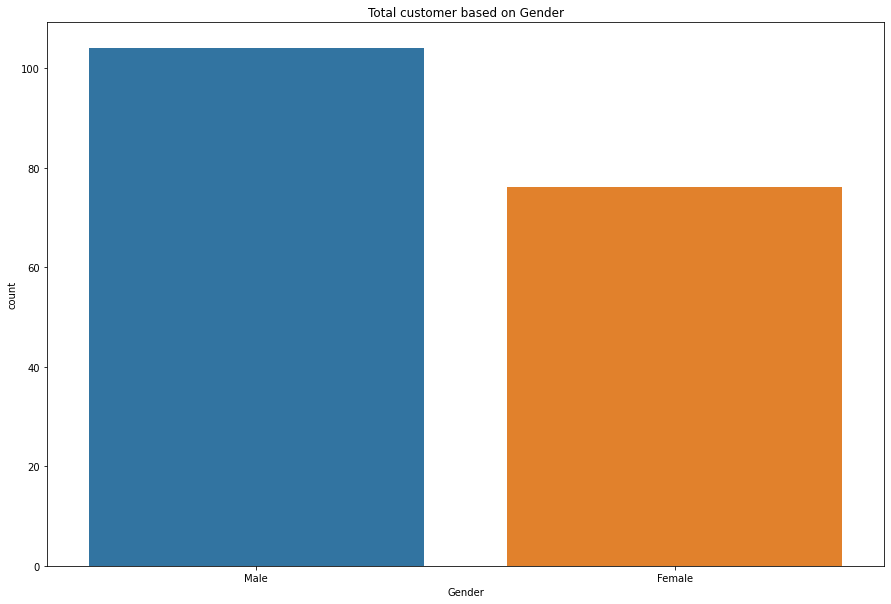

```python
# Display the distribution based on Gender

# set graph size
fig, ax= plt.subplots(figsize=(15,10))

#set title
plt.title('Total customer based on Gender')

# display the distributions
fig = sns.countplot(data=df,x='Gender');
```

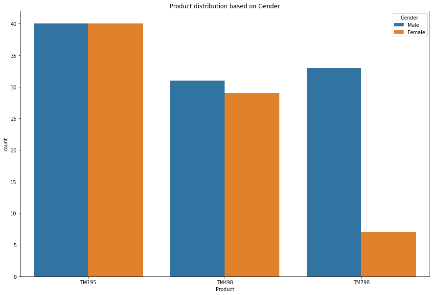

```python
# Display the distribution based on Gender

# set graph size
fig, ax= plt.subplots(figsize=(15,10))

#set title
plt.title('Product distribution based on Gender')

# set y label
plt.ylabel('Total no. of Customer')

# display the distributions
fig = sns.countplot(data=df,x='Product',hue='Gender')
```

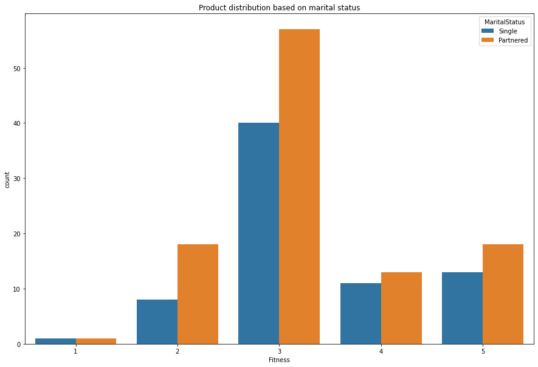

```python
# Display the fitness level distribution based on marital status

# set graph size
fig, ax= plt.subplots(figsize=(15,10))

#set title
plt.title('Product distribution based on marital status')

# set y label
plt.ylabel('Fitness level')

# diplay the distribution
fig= sns.countplot(data=df,x='Fitness',hue='MaritalStatus');
```

# Multivariate Data Analysis

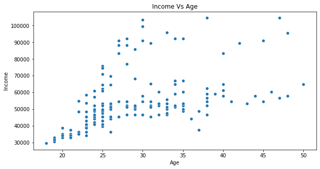

```python
# To find distribution of Income based on Age

# set graph size
fig, ax = plt.subplots(figsize=(10,5))

# Set title
plt.title('Income Vs Age')

# Display the distribution
fig= sns.scatterplot(data=df,x='Age',y='Income');
```

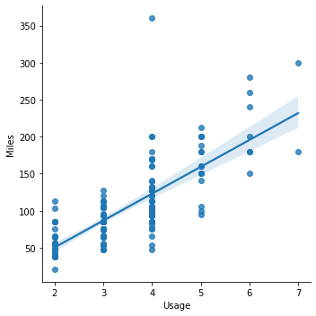

```python
# To find distribution of Usage based on Miles

# Display the distribution
sns.lmplot(data=df,x='Usage',y='Miles');
```

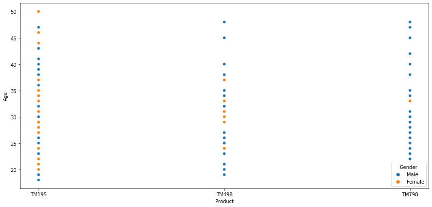

```python
# Product distribution based on Age and Gender

#set graph size
fig,ax = plt.subplots(figsize=(15,7))

# display the distribution
sns.scatterplot(data=df,x='Product',y='Age',hue='Gender');
```

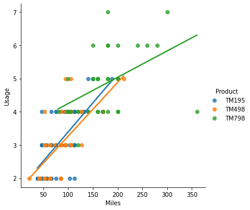

```python
# Usages of the product distibution

# Display the distibution
sns.lmplot(data=df,x='Miles',y='Usage',hue='Product',ci=False);
```

**Observations**

1. Per week usage is more for treadmil 'TM798'.

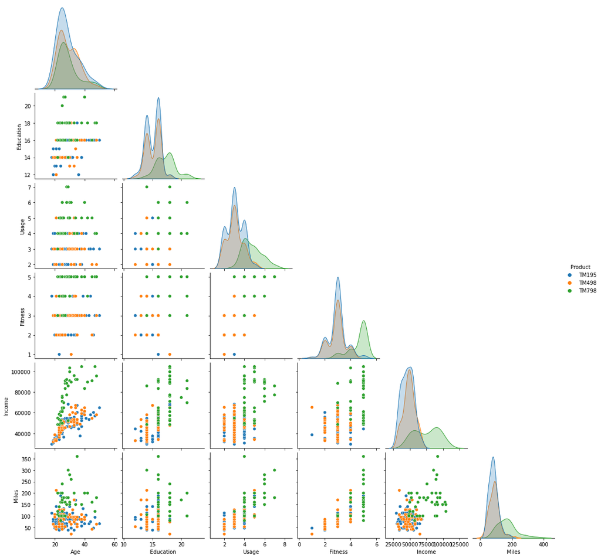

```python
sns.pairplot(data=df,hue='Product', corner=True)
```

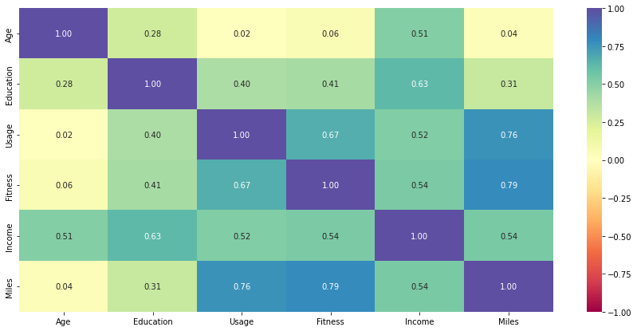

```python
# Find out the correlation between different variables

# get the correlation matrix
correlation_matrix = df.corr()

# Set plot size
plt.subplots(figsize=(15,7))

# display the correlation
sns.heatmap(data=correlation_matrix,annot=True,vmin=-1, vmax=1, fmt=".2f",cmap='Spectral');
```

**Observations:**

1. Customers who are using more tradmil , are most fit.
2. Customers having more income are also fit.

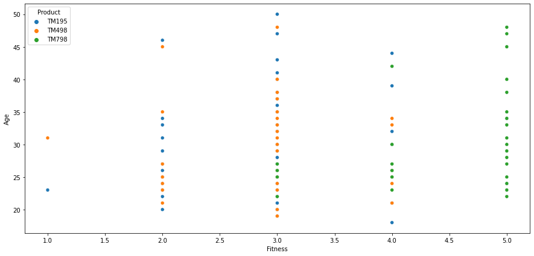

```python
# Get the fitness level for each customer based on Product and Age.
product_fitness_level_count= df.groupby(['Product','Age'])['Fitness'].value_counts().reset_index(name='count')

# Set plot size
fig,ax = plt.subplots(figsize=(15,7))

# Display the distribution
sns.scatterplot(data=product_fitness_level_count,x='Fitness',y='Age',hue='Product');
```

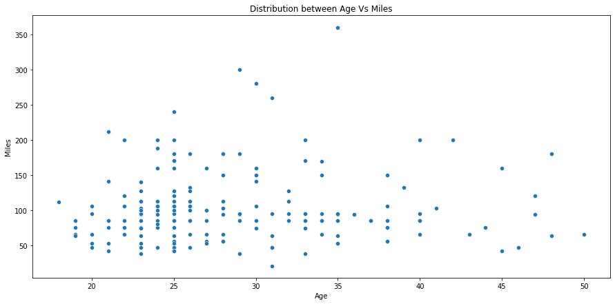

```python
# To find the distribution between Age and Miles

# Set plot size
fig,ax = plt.subplots(figsize = (15,7))

# Set title
plt.title('Distribution between Age Vs Miles')

# Display the distribution
fig = sns.scatterplot(data=df,x='Age',y='Miles')
```

```python
%%shell
jupyter nbconvert --to html '/content/drive/MyDrive/Python/Assignments/AIML_P1.ipynb'
```

```
[NbConvertApp] Converting notebook /content/drive/MyDrive/Python/Assignments/AIML_P1.ipynb to html
[NbConvertApp] Writing 814599 bytes to /content/drive/MyDrive/Python/Assignments/AIML_P1.html
```